# practica1

## PRACTICA 1: BORJA LACALLE & MANUEL ARIAS

```python
import pandas as pd
import numpy as np
import seaborn as sns
import matplotlib.pyplot as plt
```

```python
df = pd.read_csv("pd_data_initial_preprocessing.csv")
df.head(10)
```

|  | id | url | zip_code | mths_since_last_record | il_util | mths_since_recent_bc_dlq | mths_since_rcnt_il | all_util | inq_fi | max_bal_bc | ... | initial_list_status | application_type | pub_rec | pub_rec_bankruptcies | loan_amnt | mort_acc | mo_sin_old_rev_tl_op | open_acc | earliest_cr_line_month | earliest_cr_line_year |
| --- | --- | --- | --- | --- | --- | --- | --- | --- | --- | --- | --- | --- | --- | --- | --- | --- | --- | --- | --- | --- | --- |
| 0 | 112435993 | https://lendingclub.com/browse/loanDetail.acti... | 148xx | NaN | NaN | NaN | NaN | 55.0 | 1.0 | 2315.0 | ... | w | Individual | 0.0 | 0.0 | 2300.0 | 0.0 | 381.0 | 4.0 | 9.0 | 1985.0 |
| 1 | 112290210 | https://lendingclub.com/browse/loanDetail.acti... | 021xx | NaN | 69.0 | NaN | 26.0 | 94.0 | 0.0 | 1962.0 | ... | w | Individual | 0.0 | 0.0 | 16000.0 | 7.0 | 300.0 | 9.0 | 6.0 | 1992.0 |
| 2 | 112436985 | https://lendingclub.com/browse/loanDetail.acti... | 018xx | NaN | NaN | NaN | 10.0 | 45.0 | 1.0 | 1950.0 | ... | w | Individual | 0.0 | 0.0 | 6025.0 | 2.0 | 180.0 | 11.0 | 6.0 | 2002.0 |
| 3 | 112439006 | https://lendingclub.com/browse/loanDetail.acti... | 913xx | NaN | 95.0 | NaN | 6.0 | 60.0 | 1.0 | 4240.0 | ... | w | Individual | 0.0 | 0.0 | 20400.0 | 0.0 | 125.0 | 15.0 | 1.0 | 2007.0 |
| 4 | 112438929 | https://lendingclub.com/browse/loanDetail.acti... | 560xx | NaN | 72.0 | 26.0 | 127.0 | 78.0 | 0.0 | 2996.0 | ... | w | Individual | 0.0 | 0.0 | 13000.0 | 1.0 | 184.0 | 5.0 | 2.0 | 2002.0 |
| 5 | 112230200 | https://lendingclub.com/browse/loanDetail.acti... | 184xx | 83.0 | 40.0 | NaN | 41.0 | 49.0 | 0.0 | 5227.0 | ... | w | Individual | 1.0 | 1.0 | 12000.0 | 6.0 | 238.0 | 14.0 | 8.0 | 1997.0 |
| 6 | 112210041 | https://lendingclub.com/browse/loanDetail.acti... | 773xx | 71.0 | NaN | NaN | 19.0 | 59.0 | 0.0 | 3990.0 | ... | w | Individual | 1.0 | 1.0 | 6000.0 | 4.0 | 303.0 | 10.0 | 3.0 | 1992.0 |
| 7 | 112360031 | https://lendingclub.com/browse/loanDetail.acti... | 953xx | NaN | 54.0 | NaN | 16.0 | 60.0 | 1.0 | 4107.0 | ... | w | Individual | 0.0 | 0.0 | 12000.0 | 0.0 | 136.0 | 10.0 | 2.0 | 2006.0 |
| 8 | 112038251 | https://lendingclub.com/browse/loanDetail.acti... | 923xx | 84.0 | 63.0 | NaN | 27.0 | 36.0 | 1.0 | 1581.0 | ... | w | Individual | 1.0 | 1.0 | 11575.0 | 2.0 | 275.0 | 20.0 | 7.0 | 1994.0 |
| 9 | 112134207 | https://lendingclub.com/browse/loanDetail.acti... | 286xx | NaN | NaN | 40.0 | 18.0 | 8.0 | 0.0 | 5133.0 | ... | w | Individual | 0.0 | 0.0 | 20400.0 | 2.0 | 361.0 | 8.0 | 5.0 | 1987.0 |

10 rows × 51 columns

```python
df.dtypes
```

```
id                                 object
url                                object
zip_code                           object
mths_since_last_record            float64
il_util                           float64
mths_since_recent_bc_dlq          float64
mths_since_rcnt_il                float64
all_util                          float64
inq_fi                            float64
max_bal_bc                        float64
total_cu_tl                       float64
open_acc_6m                       float64
open_act_il                       float64
open_il_12m                       float64
total_bal_il                      float64
open_rv_12m                       float64
open_rv_24m                       float64
open_il_24m                       float64
inq_last_12m                      float64
mths_since_last_major_derog       float64
mths_since_recent_revol_delinq    float64
mths_since_last_delinq            float64
emp_title                          object
emp_length                        float64
mo_sin_old_il_acct                float64
revol_util                        float64
dti                               float64
verification_status                object
annual_inc                        float64
home_ownership                     object
sub_grade                         float64
grade                              object
term                              float64
int_rate                          float64
installment                       float64
loan_status                        object
total_acc                         float64
purpose                            object
addr_state                         object
fico_range_low                    float64
fico_range_high                   float64
initial_list_status                object
application_type                   object
pub_rec                           float64
pub_rec_bankruptcies              float64
loan_amnt                         float64
mort_acc                          float64
mo_sin_old_rev_tl_op              float64
open_acc                          float64
earliest_cr_line_month            float64
earliest_cr_line_year             float64
dtype: object
```

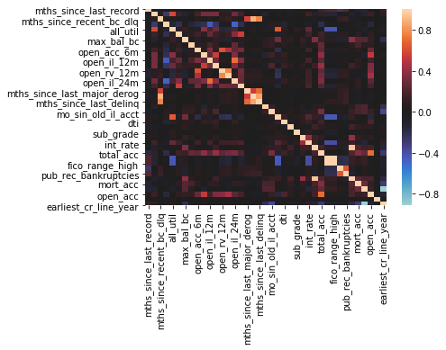

```python
variables_continuas = df.columns
matriz_correlacion = df[variables_continuas].corr()
sns.heatmap(matriz_correlacion, annot=False, center=0)
plt.show()
```

```python
# Contar el número total de valores en cada columna
total_values = df.shape[0]

# Calcular el número de valores missing en cada columna
num_missing = df.isnull().sum()

# Calcular el porcentaje de valores missing en cada columna
percent_missing = num_missing / total_values * 100
percent_missing
```

```
id                                 0.000000
url                                0.000904
zip_code                           0.000904
mths_since_last_record            82.472279
il_util                           75.524363
mths_since_recent_bc_dlq          74.523892
mths_since_rcnt_il                72.564427
all_util                          71.804553
inq_fi                            71.801502
max_bal_bc                        71.801502
total_cu_tl                       71.801502
open_acc_6m                       71.801502
open_act_il                       71.801502
open_il_12m                       71.801502
total_bal_il                      71.801502
open_rv_12m                       71.801502
open_rv_24m                       71.801502
open_il_24m                       71.801502
inq_last_12m                      71.801502
mths_since_last_major_derog       71.565426
mths_since_recent_revol_delinq    64.307864
mths_since_last_delinq            48.756108
emp_title                          5.955696
emp_length                         5.786182
mo_sin_old_il_acct                 2.895521
revol_util                         0.056166
dti                                0.030399
verification_status                0.000904
annual_inc                         0.000904
home_ownership                     0.000904
sub_grade                          0.000904
grade                              0.000904
term                               0.000904
int_rate                           0.000904
installment                        0.000904
loan_status                        0.000904
total_acc                          0.000904
purpose                            0.000904
addr_state                         0.000904
fico_range_low                     0.000904
fico_range_high                    0.000904
initial_list_status                0.000904
application_type                   0.000904
pub_rec                            0.000904
pub_rec_bankruptcies               0.000904
loan_amnt                          0.000904
mort_acc                           0.000904
mo_sin_old_rev_tl_op               0.000904
open_acc                           0.000904
earliest_cr_line_month             0.000904
earliest_cr_line_year              0.000904
dtype: float64
```

```python
cat_features = (df.dtypes[df.dtypes == 'object'].index.to_list())
num_features = (df.dtypes[df.dtypes != 'object'].index.to_list())
df[cat_features] = df[cat_features].fillna(df.mode().iloc[0])
df[num_features] = df[num_features].fillna(-99)
```

```python
df.head()
```

|  | id | url | zip_code | mths_since_last_record | il_util | mths_since_recent_bc_dlq | mths_since_rcnt_il | all_util | inq_fi | max_bal_bc | ... | initial_list_status | application_type | pub_rec | pub_rec_bankruptcies | loan_amnt | mort_acc | mo_sin_old_rev_tl_op | open_acc | earliest_cr_line_month | earliest_cr_line_year |
| --- | --- | --- | --- | --- | --- | --- | --- | --- | --- | --- | --- | --- | --- | --- | --- | --- | --- | --- | --- | --- | --- |
| 0 | 112435993 | https://lendingclub.com/browse/loanDetail.acti... | 148xx | -99.0 | -99.0 | -99.0 | -99.0 | 55.0 | 1.0 | 2315.0 | ... | w | Individual | 0.0 | 0.0 | 2300.0 | 0.0 | 381.0 | 4.0 | 9.0 | 1985.0 |
| 1 | 112290210 | https://lendingclub.com/browse/loanDetail.acti... | 021xx | -99.0 | 69.0 | -99.0 | 26.0 | 94.0 | 0.0 | 1962.0 | ... | w | Individual | 0.0 | 0.0 | 16000.0 | 7.0 | 300.0 | 9.0 | 6.0 | 1992.0 |
| 2 | 112436985 | https://lendingclub.com/browse/loanDetail.acti... | 018xx | -99.0 | -99.0 | -99.0 | 10.0 | 45.0 | 1.0 | 1950.0 | ... | w | Individual | 0.0 | 0.0 | 6025.0 | 2.0 | 180.0 | 11.0 | 6.0 | 2002.0 |
| 3 | 112439006 | https://lendingclub.com/browse/loanDetail.acti... | 913xx | -99.0 | 95.0 | -99.0 | 6.0 | 60.0 | 1.0 | 4240.0 | ... | w | Individual | 0.0 | 0.0 | 20400.0 | 0.0 | 125.0 | 15.0 | 1.0 | 2007.0 |
| 4 | 112438929 | https://lendingclub.com/browse/loanDetail.acti... | 560xx | -99.0 | 72.0 | 26.0 | 127.0 | 78.0 | 0.0 | 2996.0 | ... | w | Individual | 0.0 | 0.0 | 13000.0 | 1.0 | 184.0 | 5.0 | 2.0 | 2002.0 |

5 rows × 51 columns

```python
#Vemos que esta capada por lo tanto quitamos esa variable del dataframe ya que no nos da ninguna informacion
df['zip_code'].head()
```

```
0    148xx
1    021xx
2    018xx
3    913xx
4    560xx
Name: zip_code, dtype: object
```

```python
df= df.drop(['url', 'zip_code'], axis=1)
```

```python
df = df.set_index(['id'])
df
```

| id | mths_since_last_record | il_util | mths_since_recent_bc_dlq | mths_since_rcnt_il | all_util | inq_fi | max_bal_bc | total_cu_tl | open_acc_6m | open_act_il | ... | initial_list_status | application_type | pub_rec | pub_rec_bankruptcies | loan_amnt | mort_acc | mo_sin_old_rev_tl_op | open_acc | earliest_cr_line_month | earliest_cr_line_year |
| --- | --- | --- | --- | --- | --- | --- | --- | --- | --- | --- | --- | --- | --- | --- | --- | --- | --- | --- | --- | --- | --- |
| 112435993 | -99.0 | -99.0 | -99.0 | -99.0 | 55.0 | 1.0 | 2315.0 | 0.0 | 0.0 | 0.0 | ... | w | Individual | 0.0 | 0.0 | 2300.0 | 0.0 | 381.0 | 4.0 | 9.0 | 1985.0 |
| 112290210 | -99.0 | 69.0 | -99.0 | 26.0 | 94.0 | 0.0 | 1962.0 | 6.0 | 2.0 | 1.0 | ... | w | Individual | 0.0 | 0.0 | 16000.0 | 7.0 | 300.0 | 9.0 | 6.0 | 1992.0 |
| 112436985 | -99.0 | -99.0 | -99.0 | 10.0 | 45.0 | 1.0 | 1950.0 | 5.0 | 1.0 | 0.0 | ... | w | Individual | 0.0 | 0.0 | 6025.0 | 2.0 | 180.0 | 11.0 | 6.0 | 2002.0 |
| 112439006 | -99.0 | 95.0 | -99.0 | 6.0 | 60.0 | 1.0 | 4240.0 | 1.0 | 1.0 | 10.0 | ... | w | Individual | 0.0 | 0.0 | 20400.0 | 0.0 | 125.0 | 15.0 | 1.0 | 2007.0 |
| 112438929 | -99.0 | 72.0 | 26.0 | 127.0 | 78.0 | 0.0 | 2996.0 | 0.0 | 0.0 | 1.0 | ... | w | Individual | 0.0 | 0.0 | 13000.0 | 1.0 | 184.0 | 5.0 | 2.0 | 2002.0 |
| ... | ... | ... | ... | ... | ... | ... | ... | ... | ... | ... | ... | ... | ... | ... | ... | ... | ... | ... | ... | ... | ... |
| 36271333 | 84.0 | -99.0 | -99.0 | -99.0 | -99.0 | -99.0 | -99.0 | -99.0 | -99.0 | -99.0 | ... | w | Individual | 1.0 | 1.0 | 13000.0 | 0.0 | 108.0 | 9.0 | 9.0 | 2003.0 |
| 36490806 | -99.0 | -99.0 | -99.0 | -99.0 | -99.0 | -99.0 | -99.0 | -99.0 | -99.0 | -99.0 | ... | w | Individual | 0.0 | 0.0 | 12000.0 | 0.0 | 83.0 | 17.0 | 10.0 | 2003.0 |
| 36271262 | 110.0 | -99.0 | -99.0 | -99.0 | -99.0 | -99.0 | -99.0 | -99.0 | -99.0 | -99.0 | ... | f | Individual | 1.0 | 0.0 | 20000.0 | 0.0 | 155.0 | 8.0 | 12.0 | 2001.0 |
| Total amount funded in policy code 1: 6417608175 | -99.0 | -99.0 | -99.0 | -99.0 | -99.0 | -99.0 | -99.0 | -99.0 | -99.0 | -99.0 | ... | w | Individual | -99.0 | -99.0 | -99.0 | -99.0 | -99.0 | -99.0 | -99.0 | -99.0 |
| Total amount funded in policy code 2: 1944088810 | -99.0 | -99.0 | -99.0 | -99.0 | -99.0 | -99.0 | -99.0 | -99.0 | -99.0 | -99.0 | ... | w | Individual | -99.0 | -99.0 | -99.0 | -99.0 | -99.0 | -99.0 | -99.0 | -99.0 |

884884 rows × 48 columns

```python
df['loan_status'].value_counts()
```

```
Current               422693
Fully Paid            345520
Charged Off            97047
Late (31-120 days)     11168
In Grace Period         5507
Late (16-30 days)       2915
Default                   34
Name: loan_status, dtype: int64
```

```python
# Agrupar los valores "Charged off" y "Default" en una nueva categoría "Not Paid"
df['loan_status'] = df['loan_status'].replace(['Charged Off', 'Default'], 'Not Paid')

# Filtrar los valores "Fully Paid" y "Not Paid" en un nuevo DataFrame
data = df.loc[df['loan_status'].isin(['Fully Paid', 'Not Paid'])]
```

```python
data.shape
```

```
(442601, 48)
```

```python
print(data['emp_title'].unique().shape[0])
data['emp_title'].value_counts()
```

```
125020
```

```
Teacher                                  32997
Manager                                   7274
Registered Nurse                          3413
RN                                        3220
Supervisor                                3171
                                         ...
Content Processing Coordinator               1
Senior Director of Business Operatons        1
Whse Receiving                               1
Medical Lab Tecnician                        1
Cdi specialist                               1
Name: emp_title, Length: 125020, dtype: int64
```

```python
data = data.drop('emp_title', axis=1)
```

Podemos ver la variable emp_title, que te dice The job title supplied by the Borrower when applying for the loan, tiene 125,000 valores distintos. luego vemos qe hay muchos valores que aprecen solo una vez mientras que hay otros como teacher que aparecen mas de 30,000 veces. tendremos qu valorar si la eliminamos o no y finalmente lo hacemos ya que no sabemos como normalizar sino

```python
#vemos que esta muy desbalanceado y por tanto tendremos que balancearlo
data['loan_status'].value_counts(normalize = True)
```

```
Fully Paid    0.780658
Not Paid      0.219342
Name: loan_status, dtype: float64
```

```python
#cogemos 10,000 de Fully paid y 10,000 de Not Paid para balancear la variable objetivo
positive_df = data[data['loan_status'] == 'Fully Paid'].sample(n=10000, random_state=42, replace=True)
negative_df = data[data['loan_status'] == 'Not Paid'].sample(n=10000, random_state=42, replace=True)
#concatenamos los dos dataframes
loan_df = pd.concat([positive_df, negative_df], axis = 0)
#lo barajamos
loan_df = loan_df.sample(frac=1, random_state=42).reset_index(drop=True)
```

```python
from sklearn.preprocessing import LabelEncoder

# Transformamos la variable objetivo cambiando Fully paid por un 0 y Not Paid por un 1
le = LabelEncoder()
loan_df['loan_status'] = le.fit_transform(loan_df['loan_status'])

# Transformar las variables categóricas a numericas
cat_vars = ['grade', 'sub_grade', 'home_ownership', 'verification_status', 'purpose', 'addr_state', 'initial_list_status', 'application_type']
for var in cat_vars:
    le = LabelEncoder()
    loan_df[var] = le.fit_transform(loan_df[var])

# Ver los datos transformados
loan_df.head()
```

|  | mths_since_last_record | il_util | mths_since_recent_bc_dlq | mths_since_rcnt_il | all_util | inq_fi | max_bal_bc | total_cu_tl | open_acc_6m | open_act_il | ... | initial_list_status | application_type | pub_rec | pub_rec_bankruptcies | loan_amnt | mort_acc | mo_sin_old_rev_tl_op | open_acc | earliest_cr_line_month | earliest_cr_line_year |
| --- | --- | --- | --- | --- | --- | --- | --- | --- | --- | --- | --- | --- | --- | --- | --- | --- | --- | --- | --- | --- | --- |
| 0 | 113.0 | -99.0 | -99.0 | -99.0 | -99.0 | -99.0 | -99.0 | -99.0 | -99.0 | -99.0 | ... | 1 | 0 | 1.0 | 1.0 | 5500.0 | 1.0 | 189.0 | 17.0 | 10.0 | 1999.0 |
| 1 | 65.0 | -99.0 | 46.0 | -99.0 | -99.0 | -99.0 | -99.0 | -99.0 | -99.0 | -99.0 | ... | 0 | 0 | 2.0 | 1.0 | 5000.0 | 1.0 | 293.0 | 7.0 | 9.0 | 1990.0 |
| 2 | -99.0 | -99.0 | -99.0 | -99.0 | -99.0 | -99.0 | -99.0 | -99.0 | -99.0 | -99.0 | ... | 1 | 0 | 0.0 | 0.0 | 24750.0 | 5.0 | 140.0 | 13.0 | 3.0 | 2004.0 |
| 3 | -99.0 | -99.0 | -99.0 | -99.0 | -99.0 | -99.0 | -99.0 | -99.0 | -99.0 | -99.0 | ... | 0 | 0 | 0.0 | 0.0 | 10000.0 | 4.0 | 107.0 | 8.0 | 4.0 | 2004.0 |
| 4 | -99.0 | -99.0 | 30.0 | -99.0 | -99.0 | -99.0 | -99.0 | -99.0 | -99.0 | -99.0 | ... | 1 | 0 | 0.0 | 0.0 | 27650.0 | 7.0 | 210.0 | 6.0 | 2.0 | 1997.0 |

5 rows × 47 columns

```python
print(loan_df.shape)
loan_df['loan_status'].value_counts(normalize = True)
```

```
(20000, 47)
```

```
1    0.5
0    0.5
Name: loan_status, dtype: float64
```

```python
from sklearn.model_selection import train_test_split

# Separar la variable objetivo
y = loan_df['loan_status']

# Separar las variables predictoras
X = loan_df.drop('loan_status', axis=1)

# Separar en conjunto de entrenamiento y prueba
X_train, X_test, y_train, y_test = train_test_split(X, y, test_size=0.3, random_state=42)
```

## Regresión Logística

```python
from sklearn.preprocessing import StandardScaler
from sklearn.linear_model import LogisticRegression

# Crear objetos para escalar los datos
scaler = StandardScaler()

# Ajustar el escalador en el conjunto de datos de entrenamiento
scaler.fit(X_train)

# Normalizar los datos de entrenamiento y test
X_train_norm = scaler.transform(X_train)
X_test_norm = scaler.transform(X_test)
```

```python
# Entrenamos el modelo de Regresión Logística con los datos de entrenamiento
logreg = LogisticRegression()
logreg.fit(X_train_norm, y_train)
```

```
LogisticRegression()
```

```python
# Importar las métricas
from sklearn.metrics import accuracy_score, precision_score, recall_score, confusion_matrix, f1_score, roc_curve, auc, balanced_accuracy_score

# Evaluar precisión del modelo en el conjunto de entrenamiento
train_score = logreg.score(X_train_norm, y_train)
print('Precisión en conjunto de entrenamiento:', train_score)

# Evaluar precisión del modelo en el conjunto de prueba
test_score = logreg.score(X_test_norm, y_test)
print('Precisión en conjunto de prueba:', test_score)

# Predecir las clases del conjunto de prueba
y_pred = logreg.predict(X_test_norm)

# Calcular métricas de clasificación
accuracy = accuracy_score(y_test, y_pred)
precision = precision_score(y_test, y_pred)
recall = recall_score(y_test, y_pred)
f1 = f1_score(y_test, y_pred)
balanced_accuracy = balanced_accuracy_score(y_test, y_pred)
confusion = confusion_matrix(y_test, y_pred)

# Calcular curva ROC y área bajo la curva
fpr, tpr, thresholds = roc_curve(y_test, y_pred)
roc_auc = auc(fpr, tpr)

# Imprimir resultados
print('\nMétricas de evaluación:')
print('Accuracy:', accuracy)
print('Precision:', precision)
print('Recall:', recall)
print('Confusion Matrix:\n', confusion)
print('F1-Score:', f1)
print('ROC AUC:', roc_auc)
print('Balanced Accuracy:', balanced_accuracy)
```

```
Precisión en conjunto de entrenamiento: 0.6631428571428571
Precisión en conjunto de prueba: 0.6676666666666666

Métricas de evaluación:
Accuracy: 0.6676666666666666
Precision: 0.6636678200692041
Recall: 0.6523809523809524
Confusion Matrix:
 [[2088  972]
 [1022 1918]]
F1-Score: 0.657975986277873
ROC AUC: 0.6673669467787116
Balanced Accuracy: 0.6673669467787116
```

## Regresión Logística

#### Rellenando valores missing mediante el metodo KNNimputer

```python
data1 = pd.read_csv("pd_data_initial_preprocessing.csv")
```

```python
# Agrupar los valores "Charged off" y "Default" en una nueva categoría "Not Paid"
data1['loan_status'] = data1['loan_status'].replace(['Charged Off', 'Default'], 'Not Paid')

# Filtrar los valores "Fully Paid" y "Not Paid" en un nuevo DataFrame
data1 = data1.loc[data1['loan_status'].isin(['Fully Paid', 'Not Paid'])]
```

```python
#cogemos 10,000 de Fully paid y 10,000 de Not Paid para balancear la variable objetivo
positive_df1 = data1[data1['loan_status'] == 'Fully Paid'].sample(n=10000, random_state=42, replace=True)
negative_df1 = data1[data1['loan_status'] == 'Not Paid'].sample(n=10000, random_state=42, replace=True)
#concatenamos los dos dataframes
loan_df1 = pd.concat([positive_df1, negative_df1], axis = 0)
#lo barajamos
loan_df1 = loan_df1.sample(frac=1, random_state=42).reset_index(drop=True)
```

```python
loan_df1= loan_df1.drop(['url', 'zip_code', 'emp_title'], axis=1)
```

```python
from sklearn.preprocessing import LabelEncoder
# Transformamos la variable objetivo cambiando Fully paid por un 0 y Not Paid por un 1
le = LabelEncoder()
loan_df1['loan_status'] = le.fit_transform(loan_df1['loan_status'])

# Transformar las variables categóricas a numericas
cat_vars = ['grade', 'sub_grade', 'home_ownership', 'verification_status', 'purpose', 'addr_state', 'initial_list_status', 'application_type']
for var in cat_vars:
    le = LabelEncoder()
    loan_df1[var] = le.fit_transform(loan_df1[var])
```

```python
from sklearn.model_selection import train_test_split

# Separar la variable objetivo
y1 = loan_df1['loan_status']

# Separar las variables predictoras
X1 = loan_df1.drop('loan_status', axis=1)

# Separar en conjunto de entrenamiento y prueba
X_train1, X_test1, y_train1, y_test1 = train_test_split(X1, y1, test_size=0.3, random_state=42)
```

```python
from sklearn.impute import KNNImputer
from sklearn.model_selection import train_test_split
from sklearn.linear_model import LogisticRegression
from sklearn.metrics import accuracy_score

# Dividir los datos en conjuntos de entrenamiento y prueba
X_train1, X_test1, y_train1, y_test1 = train_test_split(X1, y1, test_size=0.2, random_state=42)

# Crear un imputador KNN
imputer = KNNImputer(n_neighbors=1)

# Imputar los valores faltantes en el conjunto de entrenamiento y prueba
X_train_imputed = imputer.fit_transform(X_train1)
X_test_imputed = imputer.transform(X_test1)

# Ajustar el modelo de regresión logística en los datos imputados
model = LogisticRegression()
model.fit(X_train_imputed, y_train1)

# Evaluar el rendimiento del modelo en los datos de prueba
y_pred1 = model.predict(X_test_imputed)
accuracy = accuracy_score(y_test1, y_pred1)
print(f"Accuracy: {accuracy}")
```

```
Accuracy: 0.57875
```

Vemos que rellenando los valores missing mediante el metodo knnimputer perdemos accuracy en el modelo de logistic regression por lo tanto no quedamos con el metodo de rellenar valores missing con un -99 (valor muy distinto a los demas)

## KNN

```python
from sklearn.neighbors import KNeighborsRegressor
from sklearn.metrics import accuracy_score, precision_score, recall_score, f1_score, roc_curve, auc, confusion_matrix, balanced_accuracy_score

# Crear modelo de árbol de decisión
knn = KNeighborsRegressor(n_neighbors=1, weights='distance')

# Entrenar modelo con datos de entrenamiento
knn.fit(X_train_norm, y_train)

# Evaluar precisión del modelo en el conjunto de entrenamiento
train_score = knn.score(X_train_norm, y_train)
print('Precisión en conjunto de entrenamiento:', train_score)

# Evaluar precisión del modelo en el conjunto de prueba
test_score = knn.score(X_test_norm, y_test)
print('Precisión en conjunto de prueba:', test_score)

# Predecir las clases del conjunto de prueba
y_pred = knn.predict(X_test_norm)

# Calcular métricas de clasificación
accuracy = accuracy_score(y_test, y_pred)
precision = precision_score(y_test, y_pred)
recall = recall_score(y_test, y_pred)
f1 = f1_score(y_test, y_pred)
balanced_accuracy = balanced_accuracy_score(y_test, y_pred)
confusion = confusion_matrix(y_test, y_pred)

# Calcular curva ROC y área bajo la curva
fpr, tpr, thresholds = roc_curve(y_test, y_pred)
roc_auc = auc(fpr, tpr)

# Imprimir resultados
print('\nMétricas de evaluación:')
print('Accuracy:', accuracy)
print('Precision:', precision)
print('Recall:', recall)
print('Confusion Matrix:\n', confusion)
print('F1-Score:', f1)
print('ROC AUC:', roc_auc)
print('Balanced Accuracy:', balanced_accuracy)
```

```
Precisión en conjunto de entrenamiento: 1.0
Precisión en conjunto de prueba: -0.6486594637855141

Métricas de evaluación:
Accuracy: 0.588
Precision: 0.577125906394199
Recall: 0.595578231292517
Confusion Matrix:
 [[1777 1283]
 [1189 1751]]
F1-Score: 0.5862068965517241
ROC AUC: 0.5881485927704414
Balanced Accuracy: 0.5881485927704415
```

## Arbol de Decisión Simple

```python
from sklearn.tree import DecisionTreeClassifier
from sklearn.metrics import accuracy_score, precision_score, recall_score, f1_score, roc_curve, auc, confusion_matrix, balanced_accuracy_score

# Crear modelo de árbol de decisión
dt_model = DecisionTreeClassifier(random_state=42)

# Entrenar modelo con datos de entrenamiento
dt_model.fit(X_train, y_train)

# Evaluar precisión del modelo en el conjunto de entrenamiento
train_score = dt_model.score(X_train, y_train)
print('Precisión en conjunto de entrenamiento:', train_score)

# Evaluar precisión del modelo en el conjunto de prueba
test_score = dt_model.score(X_test, y_test)
print('Precisión en conjunto de prueba:', test_score)

# Predecir las clases del conjunto de prueba
y_pred = dt_model.predict(X_test)

# Calcular métricas de clasificación
accuracy = accuracy_score(y_test, y_pred)
precision = precision_score(y_test, y_pred)
recall = recall_score(y_test, y_pred)
f1 = f1_score(y_test, y_pred)
balanced_accuracy = balanced_accuracy_score(y_test, y_pred)
confusion = confusion_matrix(y_test, y_pred)

# Calcular curva ROC y área bajo la curva
fpr, tpr, thresholds = roc_curve(y_test, y_pred)
roc_auc = auc(fpr, tpr)

# Imprimir resultados
print('\nMétricas de evaluación:')
print('Accuracy:', accuracy)
print('Precision:', precision)
print('Recall:', recall)
print('Confusion Matrix:\n', confusion)
print('F1-Score:', f1)
print('ROC AUC:', roc_auc)
print('Balanced Accuracy:', balanced_accuracy)
```

```
Precisión en conjunto de entrenamiento: 1.0
Precisión en conjunto de prueba: 0.5866666666666667

Métricas de evaluación:
Accuracy: 0.5866666666666667
Precision: 0.5759075907590759
Recall: 0.5935374149659864
Confusion Matrix:
 [[1775 1285]
 [1195 1745]]
F1-Score: 0.5845896147403686
ROC AUC: 0.5868013872215553
Balanced Accuracy: 0.5868013872215554
```

## Bagging Classifier

```python
from sklearn.ensemble import BaggingClassifier

# Crear modelo de bagging classifier
bag_model = BaggingClassifier(n_estimators=10, random_state=42)

# Entrenar modelo con datos de entrenamiento
bag_model.fit(X_train, y_train)

# Evaluar precisión del modelo en el conjunto de entrenamiento
train_score = bag_model.score(X_train, y_train)
print('Precisión en conjunto de entrenamiento:', train_score)

# Evaluar precisión del modelo en el conjunto de prueba
test_score = bag_model.score(X_test, y_test)
print('Precisión en conjunto de prueba:', test_score)

# Predecir las clases del conjunto de prueba
y_pred = bag_model.predict(X_test)

# Calcular métricas de clasificación
accuracy = accuracy_score(y_test, y_pred)
precision = precision_score(y_test, y_pred)
recall = recall_score(y_test, y_pred)
f1 = f1_score(y_test, y_pred)
balanced_accuracy = balanced_accuracy_score(y_test, y_pred)
confusion = confusion_matrix(y_test, y_pred)

# Calcular curva ROC y área bajo la curva
fpr, tpr, thresholds = roc_curve(y_test, y_pred)
roc_auc = auc(fpr, tpr)

# Imprimir resultados
print('\nMétricas de evaluación:')
print('Accuracy:', accuracy)
print('Precision:', precision)
print('Recall:', recall)
print('Confusion Matrix:\n', confusion)
print('F1-Score:', f1)
print('ROC AUC:', roc_auc)
print('Balanced Accuracy:', balanced_accuracy)
```

```
Precisión en conjunto de entrenamiento: 0.9862142857142857
Precisión en conjunto de prueba: 0.633

Métricas de evaluación:
Accuracy: 0.633
Precision: 0.6417050691244239
Recall: 0.5683673469387756
Confusion Matrix:
 [[2127  933]
 [1269 1671]]
F1-Score: 0.6028138528138528
ROC AUC: 0.6317326930772309
Balanced Accuracy: 0.6317326930772309
```

## Random Forest

```python
from sklearn.ensemble import RandomForestClassifier

# Crear modelo de random forest
rf = RandomForestClassifier(n_estimators=100, max_depth=None, criterion='gini')

# Entrenar modelo con datos de entrenamiento
rf.fit(X_train, y_train)

# Evaluar precisión del modelo en el conjunto de entrenamiento
train_score = rf.score(X_train, y_train)
print('Precisión en conjunto de entrenamiento:', train_score)

# Evaluar precisión del modelo en el conjunto de prueba
test_score = rf.score(X_test, y_test)
print('Precisión en conjunto de prueba:', test_score)

# Predecir las clases del conjunto de prueba
y_pred = rf.predict(X_test)

# Calcular métricas de clasificación
accuracy = accuracy_score(y_test, y_pred)
precision = precision_score(y_test, y_pred)
recall = recall_score(y_test, y_pred)
f1 = f1_score(y_test, y_pred)
balanced_accuracy = balanced_accuracy_score(y_test, y_pred)
confusion = confusion_matrix(y_test, y_pred)

# Calcular curva ROC y área bajo la curva
fpr, tpr, thresholds = roc_curve(y_test, y_pred)
roc_auc = auc(fpr, tpr)

# Imprimir resultados
print('\nMétricas de evaluación:')
print('Accuracy:', accuracy)
print('Precision:', precision)
print('Recall:', recall)
print('Confusion Matrix:\n', confusion)
print('F1-Score:', f1)
print('ROC AUC:', roc_auc)
print('Balanced Accuracy:', balanced_accuracy)
```

```
Precisión en conjunto de entrenamiento: 1.0
Precisión en conjunto de prueba: 0.6673333333333333

Métricas de evaluación:
Accuracy: 0.6673333333333333
Precision: 0.6586021505376344
Recall: 0.6666666666666666
Confusion Matrix:
 [[2044 1016]
 [ 980 1960]]
F1-Score: 0.6626098715348209
ROC AUC: 0.6673202614379085
Balanced Accuracy: 0.6673202614379085
```

## Gradient Boost

```python
from sklearn.ensemble import GradientBoostingClassifier

# Crear modelo de gradient boost
gb = GradientBoostingClassifier(n_estimators=100, max_depth=3, learning_rate=0.1)

# Entrenar modelo con datos de entrenamiento
gb.fit(X_train, y_train)

# Evaluar precisión del modelo en el conjunto de entrenamiento
train_score = gb.score(X_train, y_train)
print('Precisión en conjunto de entrenamiento:', train_score)

# Evaluar precisión del modelo en el conjunto de prueba
test_score = gb.score(X_test, y_test)
print('Precisión en conjunto de prueba:', test_score)

# Predecir las clases del conjunto de prueba
y_pred = gb.predict(X_test)

# Calcular métricas de clasificación
accuracy = accuracy_score(y_test, y_pred)
precision = precision_score(y_test, y_pred)
recall = recall_score(y_test, y_pred)
f1 = f1_score(y_test, y_pred)
balanced_accuracy = balanced_accuracy_score(y_test, y_pred)
confusion = confusion_matrix(y_test, y_pred)

# Calcular curva ROC y área bajo la curva
fpr, tpr, thresholds = roc_curve(y_test, y_pred)
roc_auc = auc(fpr, tpr)

# Imprimir resultados
print('\nMétricas de evaluación:')
print('Accuracy:', accuracy)
print('Precision:', precision)
print('Recall:', recall)
print('Confusion Matrix:\n', confusion)
print('F1-Score:', f1)
print('ROC AUC:', roc_auc)
print('Balanced Accuracy:', balanced_accuracy)
```

```
Precisión en conjunto de entrenamiento: 0.685
Precisión en conjunto de prueba: 0.6548333333333334

Métricas de evaluación:
Accuracy: 0.6548333333333334
Precision: 0.6413927757891311
Recall: 0.6704081632653062
Confusion Matrix:
 [[1958 1102]
 [ 969 1971]]
F1-Score: 0.655579577581906
ROC AUC: 0.6551387221555289
Balanced Accuracy: 0.6551387221555289
```

## XGBoost

```python
import xgboost as xgb

# Crear modelo de XGBoost
xgb_model = xgb.XGBClassifier()

# Entrenar modelo con datos de entrenamiento
xgb_model.fit(X_train, y_train)

# Evaluar precisión del modelo en el conjunto de entrenamiento
train_score = xgb_model.score(X_train, y_train)
print('Precisión en conjunto de entrenamiento:', train_score)

# Evaluar precisión del modelo en el conjunto de prueba
test_score = xgb_model.score(X_test, y_test)
print('Precisión en conjunto de prueba:', test_score)

# Predecir las clases del conjunto de prueba
y_pred = xgb_model.predict(X_test)

# Calcular métricas de clasificación
accuracy = accuracy_score(y_test, y_pred)
precision = precision_score(y_test, y_pred)
recall = recall_score(y_test, y_pred)
f1 = f1_score(y_test, y_pred)
balanced_accuracy = balanced_accuracy_score(y_test, y_pred)
confusion = confusion_matrix(y_test, y_pred)

# Calcular curva ROC y área bajo la curva
fpr, tpr, thresholds = roc_curve(y_test, y_pred)
roc_auc = auc(fpr, tpr)

# Imprimir resultados
print('\nMétricas de evaluación:')
print('Accuracy:', accuracy)
print('Precision:', precision)
print('Recall:', recall)
print('Confusion Matrix:\n', confusion)
print('F1-Score:', f1)
print('ROC AUC:', roc_auc)
print('Balanced Accuracy:', balanced_accuracy)
```

```
Precisión en conjunto de entrenamiento: 0.8985
Precisión en conjunto de prueba: 0.6485

Métricas de evaluación:
Accuracy: 0.6485
Precision: 0.6371739848134698
Recall: 0.6564625850340136
Confusion Matrix:
 [[1961 1099]
 [1010 1930]]
F1-Score: 0.6466744848383315
ROC AUC: 0.6486561291183139
Balanced Accuracy: 0.6486561291183139
```

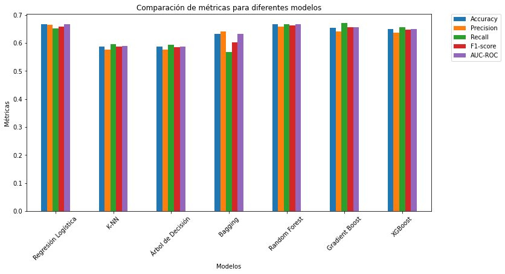

```python
import matplotlib.pyplot as plt

# Crear un DataFrame con las métricas para cada modelo
data3 = {'Accuracy': [0.6676666666666666, 0.588, 0.5866666666666667, 0.633, 0.6673333333333333, 0.6548333333333334, 0.6485],
        'Precision': [0.6636678200692041, 0.577125906394199, 0.5759075907590759, 0.6417050691244239, 0.6586021505376344, 0.6413927757891311,  0.6371739848134698],
        'Recall': [0.6523809523809524, 0.595578231292517, 0.5935374149659864, 0.5683673469387756, 0.6666666666666666, 0.6704081632653062, 0.6564625850340136],
        'F1-score': [0.657975986277873, 0.5862068965517241, 0.5845896147403686, 0.6028138528138528, 0.6626098715348209, 0.655579577581906, 0.6466744848383315],
        'AUC-ROC': [0.6673669467787116, 0.5881485927704414, 0.5868013872215553, 0.6317326930772309, 0.6673202614379085, 0.6551387221555289, 0.6486561291183139],
        'Modelo': ['Regresión Logística', 'K-NN', 'Árbol de Decisión', 'Bagging', 'Random Forest', 'Gradient Boost', 'XGBoost']}
df3 = pd.DataFrame(data3)
df3.set_index('Modelo', inplace=True)

# Crear el gráfico de barras con las métricas
fig, ax = plt.subplots(figsize=(12, 6))
df3.plot(kind='bar', ax=ax)
ax.set(title='Comparación de métricas para diferentes modelos', xlabel='Modelos', ylabel='Métricas')
ax.legend(bbox_to_anchor=(1.05, 1), loc='upper left', borderaxespad=0.)
plt.xticks(rotation=45)
plt.show()
```

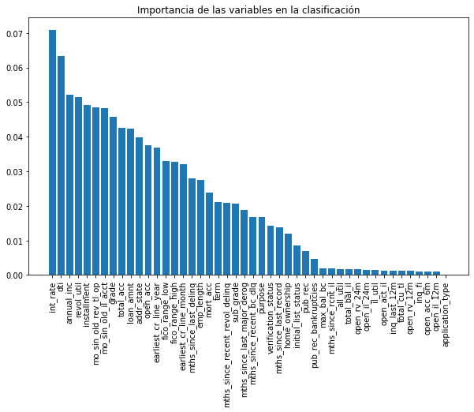

```python
from sklearn.ensemble import RandomForestClassifier


# Separar variables predictoras de la variable objetivo
X2 = loan_df.drop("loan_status", axis=1)
y2 = loan_df["loan_status"]

# Crear modelo de clasificación Random Forest
rf1 = RandomForestClassifier(n_estimators=100, random_state=42)
rf1.fit(X2, y2)

# Obtener importancia de cada variable
importances = rf1.feature_importances_

# Crear gráfica ordenada de la importancia de cada variable
indices = importances.argsort()[::-1]
features = X2.columns

import matplotlib.pyplot as plt

plt.figure(figsize=(10,6))
plt.title("Importancia de las variables en la clasificación")
plt.bar(range(len(indices)), importances[indices])
plt.xticks(range(len(indices)), [features[i] for i in indices], rotation=90)
plt.show()
```